# Blog #1

Shaya Engelman

2024-05-07

Title: Intriguing World of Bimodal Distributions: Peaks and Valleys in Data

Introduction:

In the realm of statistics, we often encounter distributions that follow a single peak, neatly symmetrical and bell-shaped. However, there exists a phenomenon known as the bimodal distribution, where the data exhibits not one, but two distinct peaks. These twin peaks do not allow us to easily model the variable using our regular methods.

Understanding Bimodal Distributions:

A bimodal distribution is characterized by two prominent peaks, each representing a cluster or mode within the data. Unlike unimodal distributions, which have a single central tendency, bimodal distributions possess dual centers of concentration, often separated by a valley or dip.

Real-Life Example: Examining Commute Times

Imagine analyzing the commute times of residents in a bustling metropolis. While some individuals may enjoy a leisurely journey during off-peak hours, others navigate through rush hour traffic, resulting in two distinct groups with varying commute durations.

1. Identifying Bimodality: Through data collection and analysis, we observe that the histogram of commute times exhibits two distinct peaks, indicating the presence of two underlying populations: those commuting during non-peak hours and those braving the rush hour congestion. Other than histograms to help visualize the distribution, we can use the Dip Test (Hartigan & Hartigan, 1985), which quantifies the departure of a distribution from unimodality. The Dip Test calculates a statistic, D, where large values of D suggest bimodality. By applying the Dip Test to our commute time data, we can obtain a formal assessment of the presence of bimodality. The lower the p-value of the D statistic the less likely that the D value is high due to an anomaly. In the folowing code snippet, we can visualize the histogram and how the dip test works.

```r
# Load required packages
library(diptest)
```

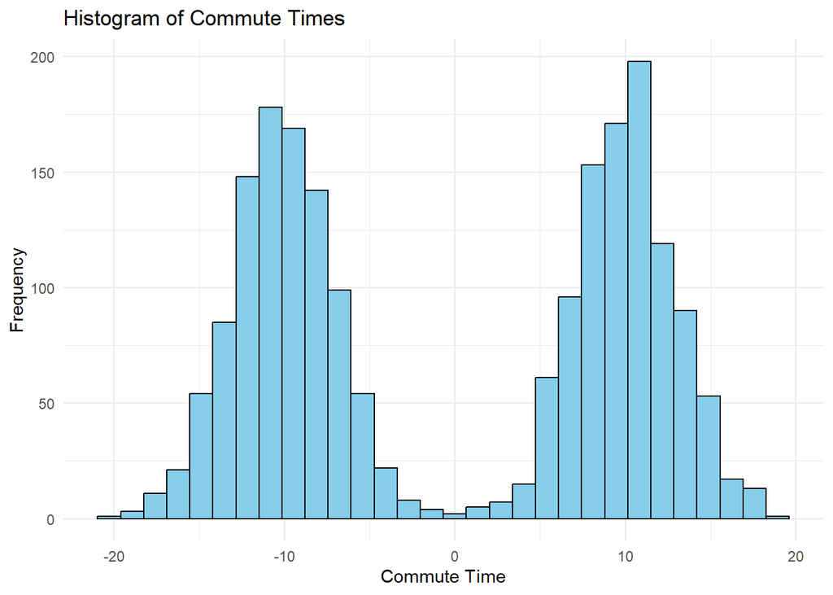

```r
library(ggplot2)
# Generate dummy commute time data
commute_times <- c(rnorm(1000, mean = -10, sd = 3), rnorm(1000, mean = 10, sd = 3))

# Plot histogram to visualize commute time distribution
ggplot() +
  geom_histogram(aes(x = commute_times), bins = 30, fill = "skyblue", color = "black") +
  labs(title = "Histogram of Commute Times", x = "Commute Time", y = "Frequency") +
  theme_minimal()
```

```r
# Perform the Dip Test
dip_result <- dip.test(commute_times)
print(dip_result)
```

```
##
##  Hartigans' dip test for unimodality / multimodality
##
## data:  commute_times
## D = 0.10887, p-value < 2.2e-16
## alternative hypothesis: non-unimodal, i.e., at least bimodal
```

2. Interpreting the Peaks: The first peak corresponds to shorter commute times, representing individuals who travel outside of peak traffic periods or utilize efficient transportation modes. The second peak, situated at a longer duration, encompasses commuters caught in the hustle and bustle of peak hours, facing congestion and delays.
3. Implications and Insights: By recognizing the bimodal nature of commute times, urban planners and policymakers gain valuable insights into transportation patterns and infrastructure needs. Solutions tailored to each group, such as promoting flexible work schedules or investing in public transit options, can enhance mobility and alleviate congestion for commuters.

Conclusion:

Bimodal distributions serve as a reminder of the rich diversity inherent in our data. Beyond the simplicity of a single peak lies a nuanced landscape of dualities, where distinct phenomena converge and diverge. Whether in commute times, income distributions, or academic performance, bimodal distributions offer a lens through which we can discern hidden patterns and understand the complexities of human behavior and societal dynamics.

As we navigate the vast expanse of data, it is important to remember to factor in the possibility of data having bimodal distributions and to not treat all continuous variables the same. One way to deal with bimodality can be to bin the data into separate groups corresponding to each peak, allowing for separate analysis or modeling approaches tailored to each subgroup. Other times we can apply mathematical transformations to the data to mitigate the bimodal nature. Common transformations include logarithmic, square root, or Box-Cox transformations. These can sometimes help make the distribution more symmetric and unimodal, making it easier to apply traditional statistical methods.